# Research Experiment Data Analytics – Project 1

Hector Vergel, Ricard Ruiz, Jordi Borraz, Nil Muns

2023-11-12

## 0.1 Introduction

This Data Analysis project explores whether designers and producers are more extroverted than programmers and artists. Using R and the ggplot2 library, we apply the scientific method, A/B testing, and descriptive statistics to analyze Eysenck personality test results. Through concise data preprocessing and inferential statistics, we aim to confirm or reject our hypotheses at 95% and 90% confidence levels. This project serves as a practical learning experience, emphasizing structured R programming, ggplot2 visualization, and the application of statistical concepts.

# 1 Experiment One

## 1.1 Research Question

Are designers and producers more extrovert than programmers and artists?

## 1.2 Draw the Experiment

The independent variable is the professional role, categorized into designers, producers, programmers, and artists.  
The dependent variable is the level of extroversion measured through the Eysenck personality test.

## 1.4 Preprocessing the Data

The first thing we will do is read the dataset.

```r
ds2019 <- read.csv("eyesench2023 - Class2019.csv")
ds2021 <- read.csv("eyesench2023 - Class2021.csv")
ds2022 <- read.csv("eyesench2023 - Class2022.csv")
ds2023 <- read.csv("eyesench2023 - Class2023.csv")
```

Then lets modify them to ensure we have no wrong data

```r
# The big dataset
ds <- rbind(ds2019, ds2021, ds2022, ds2023)

# Omit the NA
ds <- na.omit(ds)

# Remove the mixed profiles
ds <- ds[!grepl("/", ds$Profile), ]

# Profile grammatical error fix
ds$Profile[ds$Profile == "programmer"] <- "Programmer"
ds$Profile[ds$Profile == "Progammer"] <- "Programmer"

# Remove the Student index
ds$Student = NULL

# Filter and keep only the correct profiles
ds <- ds[ds$Profile %in% c("Programmer", "Designer", "Artist", "Producer"), ]
```

## 1.5 Descriptive statistics

We will be using the ggplot2 library to print the plots in this project.

```r
library(ggplot2)
```

Lets first see how many students for each profile we have:

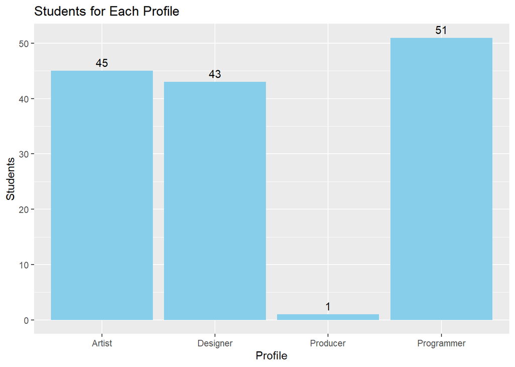

```r
ggplot(ds, aes(x = Profile)) + geom_bar(stat = "count", fill = "skyblue") + geom_text(stat = "count", aes(label = after_stat(count)), vjust = -0.5) + labs(title = "Students for Each Profile", x = "Profile", y = "Students")
```

We can see that there is just one producer, so the sample of Designers/Producers is less than the other. We need to take that into account when comparing both samples.

Now we are going to print a plot to show how the extroversion value is spread in each Profile:

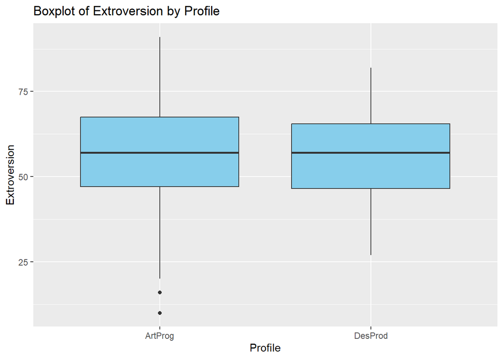

```r
ds$CombinedProfile <- ifelse(ds$Profile %in% c("Artist", "Programmer"), "ArtProg", ifelse(ds$Profile %in% c("Designer", "Producer"), "DesProd", ds$Profile))

ggplot(ds, aes(x = CombinedProfile, y = Extroversion)) + geom_boxplot(fill = "skyblue") + labs(title = "Boxplot of Extroversion by Profile", x = "Profile", y = "Extroversion")
```

In this plot we can see that the avarage Extroversion value is pretty similar in both samples. Also, the smallest and highest values are on the ArtProg sample. The DesProd sample is more balanced.